# Social Pain by SES

Qing Honors Thesis: Study 1

20:48, 18 October, 2021

# Social Pain by SES (EFA Analysis)

> **Are low-SES targets (those paired with low SES jobs) perceived as less sensitive to socially painful events than high-SES targets (those paired with high SES jobs)?**

**Methods** Within-subjects design: 67 Mturkers rated how much pain 10 high and 10 low SES targets were expected to feel following socially painful events (e.g., losing a family pet). Only participants who passed 70% or more of the manipulation checks were included in the analysis - see cleaning script (1_social_pain_SES_clean.R) for full cleaning process.

# R Session Set Up

The first *option* below, `error=TRUE`, keeps `knitr`/RMarkdown knitting even if it encounters an error in R code. The second *option*, `fig.asp=1`, sets the default aspect ratio of figures to 1.0.

```r
knitr::opts_chunk$set(error=TRUE , fig.asp=1 )
```

Housekeeping: Clear memory and graphics.

```r
rm(list=ls())  # Clears all the variables from memory.
graphics.off() # Clears all the graphs.
```

# 1. Social Pain X SES

## 1.A. Load Packages

```r
library(psych)
library(tidyverse)
library(ltm)
library(Hmisc)
library(GPArotation)
```

## 1.B. Read in Data from WD

```r
# Read in csv
dat = read.csv("social_pain_SES_clean_data_efa.csv")
head(dat)
```

```
##          ResponseId item mean_pain
## 1 R_10GwZ59gBqF6frS    1      2.00
## 2 R_10GwZ59gBqF6frS   10      3.05
## 3 R_10GwZ59gBqF6frS    2      2.75
## 4 R_10GwZ59gBqF6frS    3      2.65
## 5 R_10GwZ59gBqF6frS    4      1.80
## 6 R_10GwZ59gBqF6frS    5      3.25
```

```r
tail(dat)
```

```
##            ResponseId item mean_pain
## 665 R_Z2jYsZHPy3OIMGB    4      2.65
## 666 R_Z2jYsZHPy3OIMGB    5      2.90
## 667 R_Z2jYsZHPy3OIMGB    6      3.70
## 668 R_Z2jYsZHPy3OIMGB    7      2.55
## 669 R_Z2jYsZHPy3OIMGB    8      3.00
## 670 R_Z2jYsZHPy3OIMGB    9      2.90
```

```r
#################
d1 <- dat %>%
  filter(item=="1")
d2 <- dat %>%
  filter(item=="2")
d3 <- dat %>%
  filter(item=="3")
d4 <- dat %>%
  filter(item=="4")
d5 <- dat %>%
  filter(item=="5")
d6 <- dat %>%
  filter(item=="6")
d7 <- dat %>%
  filter(item=="7")
d8 <- dat %>%
  filter(item=="8")
d9 <- dat %>%
  filter(item=="9")
d10 <- dat %>%
  filter(item=="10")

#################

raw.dat <- data.frame(d1$mean_pain,
                      d2$mean_pain,
                      d3$mean_pain,
                      d4$mean_pain,
                      d5$mean_pain,
                      d6$mean_pain,
                      d7$mean_pain,
                      d8$mean_pain,
                      d9$mean_pain,
                      d10$mean_pain)

head(raw.dat)
```

```
##   d1.mean_pain d2.mean_pain d3.mean_pain d4.mean_pain d5.mean_pain d6.mean_pain
## 1     2.000000     2.750000     2.650000     1.800000     3.250000     3.600000
## 2     2.350000     2.550000     2.650000     2.800000     2.850000     3.000000
## 3     2.400000     2.550000     3.350000     3.200000     2.500000     2.750000
## 4     2.631579     2.473684     2.631579     2.842105     2.684211     2.947368
## 5     3.900000     3.450000     3.600000     3.750000     3.750000     3.800000
## 6     2.500000     2.650000     2.250000     2.600000     2.450000     2.150000
##   d7.mean_pain d8.mean_pain d9.mean_pain d10.mean_pain
## 1     2.700000     3.050000     3.150000      3.050000
## 2     3.100000     3.450000     3.050000      2.700000
## 3     3.350000     2.800000     2.150000      2.700000
## 4     3.157895     3.894737     3.315789      3.473684
## 5     3.750000     3.900000     3.900000      3.900000
## 6     2.850000     2.850000     2.350000      2.350000
```

## 1.C. Unidimensional Internal Reliability (alpha = .95)

The pain scale used by Trawalter et al. (2012) was internally reliable, alpha = .85. We have an even higher internal consistency with alpha = .95.

```r
psych::alpha(raw.dat)
```

```
##
## Reliability analysis
## Call: psych::alpha(x = raw.dat)
##
##   raw_alpha std.alpha G6(smc) average_r S/N    ase mean   sd median_r
##       0.95      0.95    0.96      0.67  21 0.0087  2.7 0.48     0.69
##
##  lower alpha upper     95% confidence boundaries
## 0.94 0.95 0.97
##
##  Reliability if an item is dropped:
##               raw_alpha std.alpha G6(smc) average_r S/N alpha se  var.r med.r
## d1.mean_pain       0.95      0.95    0.96      0.70  21   0.0087 0.0048  0.70
## d2.mean_pain       0.95      0.95    0.96      0.67  18   0.0099 0.0098  0.68
## d3.mean_pain       0.95      0.95    0.96      0.67  19   0.0095 0.0083  0.69
## d4.mean_pain       0.95      0.95    0.96      0.67  18   0.0100 0.0087  0.69
## d5.mean_pain       0.95      0.95    0.96      0.67  18   0.0099 0.0082  0.67
## d6.mean_pain       0.95      0.95    0.96      0.67  18   0.0098 0.0079  0.68
## d7.mean_pain       0.95      0.95    0.96      0.68  19   0.0096 0.0077  0.68
## d8.mean_pain       0.95      0.95    0.96      0.68  19   0.0093 0.0081  0.70
## d9.mean_pain       0.95      0.95    0.96      0.67  18   0.0100 0.0087  0.68
## d10.mean_pain      0.95      0.95    0.96      0.67  18   0.0098 0.0084  0.69
##
##  Item statistics
##                n raw.r std.r r.cor r.drop mean   sd
## d1.mean_pain  67  0.73  0.73  0.70   0.67  2.6 0.57
## d2.mean_pain  67  0.87  0.87  0.85   0.83  2.5 0.58
## d3.mean_pain  67  0.84  0.84  0.83   0.79  2.6 0.61
## d4.mean_pain  67  0.88  0.88  0.87   0.84  2.6 0.54
## d5.mean_pain  67  0.87  0.87  0.86   0.84  2.7 0.53
## d6.mean_pain  67  0.86  0.86  0.85   0.82  2.9 0.57
## d7.mean_pain  67  0.83  0.83  0.81   0.79  2.8 0.53
## d8.mean_pain  67  0.81  0.81  0.79   0.76  2.9 0.63
## d9.mean_pain  67  0.87  0.88  0.86   0.84  2.7 0.55
## d10.mean_pain 67  0.85  0.85  0.84   0.81  2.9 0.61
```

```r
cronbach.alpha(raw.dat)
```

```
##
## Cronbach's alpha for the 'raw.dat' data-set
##
## Items: 10
## Sample units: 67
## alpha: 0.953
```

# 2. EFA - Multidimensional Scale Possibilities

## Models

### 2.A. Correlation Matrix & Establishing Positive Determinant

```r
# Obtain and save correlation matrix
correlation = rcorr(as.matrix(raw.dat))
(corr_socialpain = correlation$r)
```

```
##               d1.mean_pain d2.mean_pain d3.mean_pain d4.mean_pain d5.mean_pain
## d1.mean_pain     1.0000000    0.6924418    0.6706752    0.6193681    0.5368263
## d2.mean_pain     0.6924418    1.0000000    0.7639427    0.7002252    0.6960164
## d3.mean_pain     0.6706752    0.7639427    1.0000000    0.8065417    0.6964356
## d4.mean_pain     0.6193681    0.7002252    0.8065417    1.0000000    0.7814553
## d5.mean_pain     0.5368263    0.6960164    0.6964356    0.7814553    1.0000000
## d6.mean_pain     0.4966671    0.7162727    0.5883199    0.6767106    0.7589751
## d7.mean_pain     0.4046148    0.6684847    0.6897936    0.7349310    0.7384117
## d8.mean_pain     0.5492810    0.6495362    0.5190142    0.6407267    0.6157572
## d9.mean_pain     0.5936319    0.7193111    0.7208358    0.7765969    0.8216425
## d10.mean_pain    0.5471549    0.6670715    0.5983862    0.6428758    0.6949049
##               d6.mean_pain d7.mean_pain d8.mean_pain d9.mean_pain d10.mean_pain
## d1.mean_pain     0.4966671    0.4046148    0.5492810    0.5936319     0.5471549
## d2.mean_pain     0.7162727    0.6684847    0.6495362    0.7193111     0.6670715
## d3.mean_pain     0.5883199    0.6897936    0.5190142    0.7208358     0.5983862
## d4.mean_pain     0.6767106    0.7349310    0.6407267    0.7765969     0.6428758
## d5.mean_pain     0.7589751    0.7384117    0.6157572    0.8216425     0.6949049
## d6.mean_pain     1.0000000    0.6825867    0.7573719    0.7146949     0.8256563
## d7.mean_pain     0.6825867    1.0000000    0.6176033    0.7258023     0.7105167
## d8.mean_pain     0.7573719    0.6176033    1.0000000    0.6404511     0.8030548
## d9.mean_pain     0.7146949    0.7258023    0.6404511    1.0000000     0.6610079
## d10.mean_pain    0.8256563    0.7105167    0.8030548    0.6610079     1.0000000
```

```r
# The determinant of the correlation matrix of the 10 item questionnaire is positive, but really small,
# so likely multicollinearity issues for efa
det(corr_socialpain)
```

```
## [1] 4.293232e-05
```

### 2.B. Conduct EFA (3 Factors) - Principal axis factoring with promax (oblique) rotation

```r
m1 = fa(corr_socialpain, # correlation matrix of item questionnaires
        nfactors = 3, # number of factors to extract
        fm = "pa", # factoring method (principle factor solution)
        rotate = "promax") # rotation method

# The extracted commonality for all 10 items is high (well explained by 3 factors)
# Communalities refer to the common variance between the items and can be interpreted as the
# degree to which the factor structure represents each item.
m1$communality
```

```
##  d1.mean_pain  d2.mean_pain  d3.mean_pain  d4.mean_pain  d5.mean_pain
##     0.8917739     0.7343378     0.8050054     0.8005137     0.7830821
##  d6.mean_pain  d7.mean_pain  d8.mean_pain  d9.mean_pain d10.mean_pain
##     0.8164387     0.7447676     0.7524173     0.7699101     0.8477910
```

```r
print(m1$loadings,
cutoff = 0.33)
```

```
##
## Loadings:
##               PA1    PA3    PA2
## d1.mean_pain                 0.923
## d2.mean_pain   0.426
## d3.mean_pain   0.824
## d4.mean_pain   0.815
## d5.mean_pain   0.773
## d6.mean_pain          0.743
## d7.mean_pain   0.797
## d8.mean_pain          0.831
## d9.mean_pain   0.737
## d10.mean_pain         0.866
##
##                  PA1   PA3   PA2
## SS loadings    3.363 2.202 1.132
## Proportion Var 0.336 0.220 0.113
## Cumulative Var 0.336 0.556 0.670
```

```r
# The correlations between our items and the factors are found in the “Structure Matrix” table.
m1$Structure
```

```
##
## Loadings:
##               PA1   PA3   PA2
## d1.mean_pain  0.625 0.552 0.943
## d2.mean_pain  0.804 0.720 0.720
## d3.mean_pain  0.863 0.587 0.720
## d4.mean_pain  0.891 0.686 0.643
## d5.mean_pain  0.875 0.744 0.536
## d6.mean_pain  0.765 0.893 0.502
## d7.mean_pain  0.835 0.725 0.426
## d8.mean_pain  0.664 0.861 0.548
## d9.mean_pain  0.872 0.724 0.600
## d10.mean_pain 0.727 0.919 0.535
##
##                  PA1   PA3   PA2
## SS loadings    6.353 5.627 4.006
## Proportion Var 0.635 0.563 0.401
## Cumulative Var 0.635 1.198 1.599
```

```r
# Full output
m1
```

```
## Factor Analysis using method =  pa
## Call: fa(r = corr_socialpain, nfactors = 3, rotate = "promax", fm = "pa")
## Standardized loadings (pattern matrix) based upon correlation matrix
##                 PA1   PA3   PA2   h2   u2 com
## d1.mean_pain  -0.03  0.08  0.92 0.89 0.11 1.0
## d2.mean_pain   0.43  0.22  0.32 0.73 0.27 2.4
## d3.mean_pain   0.82 -0.20  0.29 0.81 0.19 1.4
## d4.mean_pain   0.81  0.01  0.11 0.80 0.20 1.0
## d5.mean_pain   0.77  0.20 -0.07 0.78 0.22 1.1
## d6.mean_pain   0.23  0.74 -0.05 0.82 0.18 1.2
## d7.mean_pain   0.80  0.24 -0.22 0.74 0.26 1.3
## d8.mean_pain  -0.06  0.83  0.13 0.75 0.25 1.1
## d9.mean_pain   0.74  0.14  0.05 0.77 0.23 1.1
## d10.mean_pain  0.04  0.87  0.04 0.85 0.15 1.0
##
##                        PA1  PA3  PA2
## SS loadings           3.92 2.68 1.34
## Proportion Var        0.39 0.27 0.13
## Cumulative Var        0.39 0.66 0.79
## Proportion Explained  0.49 0.34 0.17
## Cumulative Proportion 0.49 0.83 1.00
##
##  With factor correlations of
##      PA1  PA3  PA2
## PA1 1.00 0.76 0.65
## PA3 0.76 1.00 0.54
## PA2 0.65 0.54 1.00
##
## Mean item complexity =  1.3
## Test of the hypothesis that 3 factors are sufficient.
##
## The degrees of freedom for the null model are  45  and the objective function was  10.06
## The degrees of freedom for the model are 18  and the objective function was  0.43
##
## The root mean square of the residuals (RMSR) is  0.02
## The df corrected root mean square of the residuals is  0.03
##
## Fit based upon off diagonal values = 1
## Measures of factor score adequacy
##                                                    PA1  PA3  PA2
## Correlation of (regression) scores with factors   0.97 0.96 0.95
## Multiple R square of scores with factors          0.95 0.93 0.91
## Minimum correlation of possible factor scores     0.89 0.86 0.82
```

### 2.C. Conduct EFA (3 Factors) - maximum likelihood with promax (oblique) rotation

```r
m2 = fa(corr_socialpain, # correlation matrix of item questionnaires
        nfactors = 3, # number of factors to extract
        fm = "ml", # factoring method (maximum likelihood)
        rotate = "promax") # rotation method

# The extracted commonality for all 10 items is high (well explained by 3 factors)
m2$communality
```

```
##  d1.mean_pain  d2.mean_pain  d3.mean_pain  d4.mean_pain  d5.mean_pain
##     0.9950003     0.7234416     0.7840133     0.8075306     0.7779831
##  d6.mean_pain  d7.mean_pain  d8.mean_pain  d9.mean_pain d10.mean_pain
##     0.8182715     0.7477825     0.7467088     0.7693913     0.8515432
```

```r
print(m2$loadings,
cutoff = 0.33)
```

```
##
## Loadings:
##               ML2    ML3    ML1
## d1.mean_pain                 0.963
## d2.mean_pain   0.473
## d3.mean_pain   0.866
## d4.mean_pain   0.856
## d5.mean_pain   0.747
## d6.mean_pain          0.761
## d7.mean_pain   0.777
## d8.mean_pain          0.836
## d9.mean_pain   0.744
## d10.mean_pain         0.887
##
##                  ML2   ML3   ML1
## SS loadings    3.473 2.276 1.131
## Proportion Var 0.347 0.228 0.113
## Cumulative Var 0.347 0.575 0.688
```

```r
# The correlations between our items and the factors are found in the “Structure Matrix” table.
m2$Structure
```

```
##
## Loadings:
##               ML2   ML3   ML1
## d1.mean_pain  0.640 0.555 0.996
## d2.mean_pain  0.809 0.724 0.671
## d3.mean_pain  0.864 0.602 0.656
## d4.mean_pain  0.897 0.689 0.597
## d5.mean_pain  0.872 0.753 0.507
## d6.mean_pain  0.764 0.896 0.456
## d7.mean_pain  0.831 0.736 0.371
## d8.mean_pain  0.668 0.859 0.513
## d9.mean_pain  0.872 0.726 0.567
## d10.mean_pain 0.725 0.922 0.507
##
##                  ML2   ML3   ML1
## SS loadings    6.379 5.694 3.673
## Proportion Var 0.638 0.569 0.367
## Cumulative Var 0.638 1.207 1.575
```

```r
# Full output
m2
```

```
## Factor Analysis using method =  ml
## Call: fa(r = corr_socialpain, nfactors = 3, rotate = "promax", fm = "ml")
## Standardized loadings (pattern matrix) based upon correlation matrix
##                 ML2   ML3   ML1   h2    u2 com
## d1.mean_pain   0.00  0.06  0.96 1.00 0.005 1.0
## d2.mean_pain   0.47  0.22  0.27 0.72 0.277 2.1
## d3.mean_pain   0.87 -0.17  0.21 0.78 0.216 1.2
## d4.mean_pain   0.86 -0.01  0.08 0.81 0.192 1.0
## d5.mean_pain   0.75  0.21 -0.06 0.78 0.222 1.2
## d6.mean_pain   0.22  0.76 -0.06 0.82 0.182 1.2
## d7.mean_pain   0.78  0.26 -0.24 0.75 0.252 1.4
## d8.mean_pain  -0.05  0.84  0.12 0.75 0.253 1.0
## d9.mean_pain   0.74  0.13  0.04 0.77 0.231 1.1
## d10.mean_pain  0.01  0.89  0.05 0.85 0.148 1.0
##
##                        ML2  ML3  ML1
## SS loadings           3.99 2.74 1.29
## Proportion Var        0.40 0.27 0.13
## Cumulative Var        0.40 0.67 0.80
## Proportion Explained  0.50 0.34 0.16
## Cumulative Proportion 0.50 0.84 1.00
##
##  With factor correlations of
##      ML2  ML3  ML1
## ML2 1.00 0.77 0.61
## ML3 0.77 1.00 0.51
## ML1 0.61 0.51 1.00
##
## Mean item complexity =  1.2
## Test of the hypothesis that 3 factors are sufficient.
##
## The degrees of freedom for the null model are  45  and the objective function was  10.06
## The degrees of freedom for the model are 18  and the objective function was  0.42
##
## The root mean square of the residuals (RMSR) is  0.02
## The df corrected root mean square of the residuals is  0.03
##
## Fit based upon off diagonal values = 1
## Measures of factor score adequacy
##                                                    ML2  ML3  ML1
## Correlation of (regression) scores with factors   0.97 0.97 1.00
## Multiple R square of scores with factors          0.95 0.93 0.99
## Minimum correlation of possible factor scores     0.89 0.86 0.99
```

### 2.D. Conduct EFA (2 Factors) - maximum likelihood with promax (oblique) rotation

```r
m3 = fa(corr_socialpain, # correlation matrix of item questionnaires
        nfactors = 2, # number of factors to extract
        fm = "ml", # factoring method (maximum likelihood)
        rotate = "promax") # rotation method

# The extracted commonality for most items is high (well explained by 2 factors)
m3$communality
```

```
##  d1.mean_pain  d2.mean_pain  d3.mean_pain  d4.mean_pain  d5.mean_pain
##     0.4942451     0.7119043     0.8186422     0.8046998     0.7478728
##  d6.mean_pain  d7.mean_pain  d8.mean_pain  d9.mean_pain d10.mean_pain
##     0.8231127     0.6706957     0.7294481     0.7531005     0.8347703
```

```r
print(m3$loadings,
cutoff = 0.33)
```

```
##
## Loadings:
##               ML1    ML2
## d1.mean_pain   0.667
## d2.mean_pain   0.640
## d3.mean_pain   1.043
## d4.mean_pain   0.854
## d5.mean_pain   0.588
## d6.mean_pain          0.851
## d7.mean_pain   0.511  0.354
## d8.mean_pain          0.867
## d9.mean_pain   0.678
## d10.mean_pain         0.921
##
##                  ML1   ML2
## SS loadings    3.746 2.704
## Proportion Var 0.375 0.270
## Cumulative Var 0.375 0.645
```

```r
# The correlations between our items and the factors are found in the “Structure Matrix” table.
m3$Structure
```

```
##
## Loadings:
##               ML1   ML2
## d1.mean_pain  0.702 0.568
## d2.mean_pain  0.830 0.744
## d3.mean_pain  0.897 0.632
## d4.mean_pain  0.896 0.724
## d5.mean_pain  0.841 0.784
## d6.mean_pain  0.738 0.906
## d7.mean_pain  0.789 0.755
## d8.mean_pain  0.663 0.854
## d9.mean_pain  0.856 0.759
## d10.mean_pain 0.713 0.914
##
##                  ML1   ML2
## SS loadings    6.347 5.946
## Proportion Var 0.635 0.595
## Cumulative Var 0.635 1.229
```

```r
# Full output
m3
```

```
## Factor Analysis using method =  ml
## Call: fa(r = corr_socialpain, nfactors = 2, rotate = "promax", fm = "ml")
## Standardized loadings (pattern matrix) based upon correlation matrix
##                 ML1   ML2   h2   u2 com
## d1.mean_pain   0.67  0.05 0.49 0.51 1.0
## d2.mean_pain   0.64  0.24 0.71 0.29 1.3
## d3.mean_pain   1.04 -0.19 0.82 0.18 1.1
## d4.mean_pain   0.85  0.05 0.80 0.20 1.0
## d5.mean_pain   0.59  0.32 0.75 0.25 1.6
## d6.mean_pain   0.07  0.85 0.82 0.18 1.0
## d7.mean_pain   0.51  0.35 0.67 0.33 1.8
## d8.mean_pain  -0.02  0.87 0.73 0.27 1.0
## d9.mean_pain   0.68  0.23 0.75 0.25 1.2
## d10.mean_pain -0.01  0.92 0.83 0.17 1.0
##
##                        ML1  ML2
## SS loadings           4.22 3.17
## Proportion Var        0.42 0.32
## Cumulative Var        0.42 0.74
## Proportion Explained  0.57 0.43
## Cumulative Proportion 0.57 1.00
##
##  With factor correlations of
##      ML1  ML2
## ML1 1.00 0.78
## ML2 0.78 1.00
##
## Mean item complexity =  1.2
## Test of the hypothesis that 2 factors are sufficient.
##
## The degrees of freedom for the null model are  45  and the objective function was  10.06
## The degrees of freedom for the model are 26  and the objective function was  0.81
##
## The root mean square of the residuals (RMSR) is  0.04
## The df corrected root mean square of the residuals is  0.05
##
## Fit based upon off diagonal values = 1
## Measures of factor score adequacy
##                                                    ML1  ML2
## Correlation of (regression) scores with factors   0.97 0.97
## Multiple R square of scores with factors          0.95 0.94
## Minimum correlation of possible factor scores     0.89 0.88
```

### 2.E. How many factors should we retain? 1

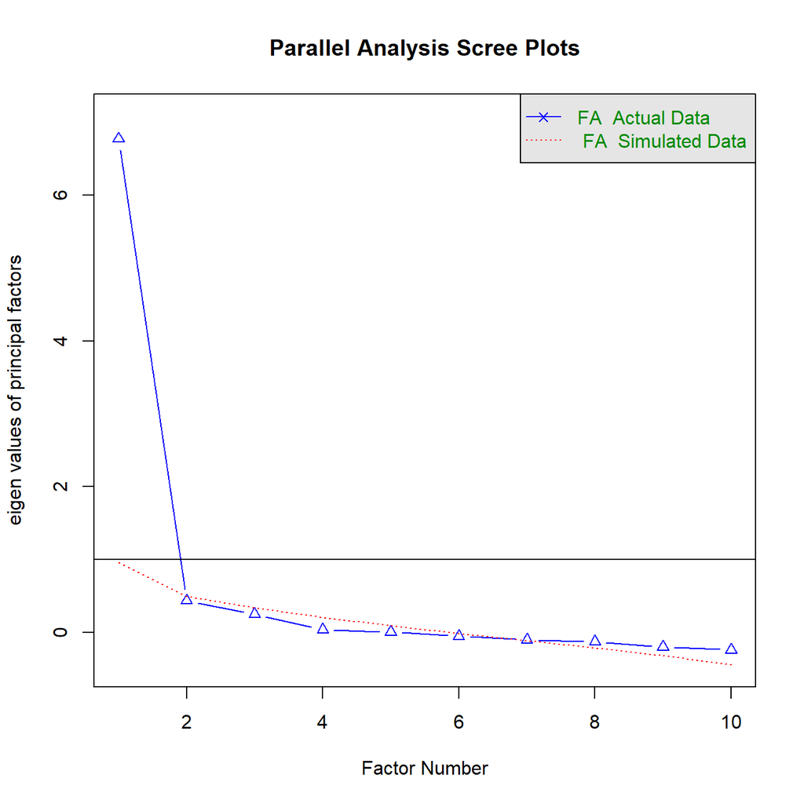

```
## Parallel analysis suggests that the number of factors =  1  and the number of components =  NA
```

```r
# Parallel analysis suggests that the number of factors =  1

fa.parallel(corr_socialpain, # correlation of the item questionnaires
            n.obs = nrow(raw.dat), # number of observations
            fa = "fa", # show the eigenvalues for factor analysis
            n.iter = 1000) # number of simulated analysis to perform
```

# R Session Info

To help with reproducibility, it is important to include the date and details of the software versions:

```r
date()
```

```
## [1] "Mon Oct 18 20:48:31 2021"
```